# Project_4_Bank_Churner_Full_code

Bank Churn Prediction

## Problem Statement

### Context

Businesses, such as banks that offer services, must address the issue of 'Customer Churn,' which refers to customers leaving to join another service provider. Understanding the factors that influence a customer's decision to stay or leave is crucial. By identifying these key aspects of their service, management can focus on targeted improvements, ensuring efforts are directed towards enhancing the most critical areas to retain customers.

### Objective

As a Data Scientist, the task is to develop a neural network-based classifier capable of predicting whether a customer will leave the bank within the next six months.

### Data Dictionary

- CustomerId: Unique ID which is assigned to each customer
- Surname: Last name of the customer
- CreditScore: It defines the credit history of the customer.
- Geography: A customer’s location
- Gender: It defines the Gender of the customer
- Age: Age of the customer
- Tenure: Number of years for which the customer has been with the bank
- NumOfProducts: refers to the number of products that a customer has purchased through the bank.
- Balance: Account balance
- HasCrCard: It is a categorical variable which decides whether the customer has credit card or not.
- EstimatedSalary: Estimated salary
- isActiveMember: Is is a categorical variable which decides whether the customer is active member of the bank or not ( Active member in the sense, using bank products regularly, making transactions etc )
- Exited : whether or not the customer left the bank within six month. It can take two values **0=No ( Customer did not leave the bank )** 1=Yes ( Customer left the bank )

## Importing necessary libraries

```python
# Install tensor flow
# !pip install tensorflow
```

```python
# Libraries to help with reading and manipulating data
import pandas as pd
import numpy as np
import random

# libaries to help with data visualization
import matplotlib.pyplot as plt
import seaborn as sns

# Library to split data
from sklearn.model_selection import train_test_split

# library to import to standardize the data
from sklearn.preprocessing import StandardScaler, LabelEncoder

# To calculate statistical measures
from scipy import stats
from scipy.stats import chi2_contingency

# library to import SMOTE
from imblearn.over_sampling import SMOTE


# importing different functions to build models
import tensorflow as tf
from tensorflow import keras
from keras import backend
from keras.models import Sequential
from keras.layers import Dense, Dropout
from tensorflow.keras.optimizers import SGD
from tensorflow.keras.optimizers import Adam
from keras.callbacks import EarlyStopping, ModelCheckpoint

# importing metrics
from sklearn.metrics import confusion_matrix,roc_curve,classification_report,recall_score


# Library to avoid the warnings
import warnings
warnings.filterwarnings("ignore")
```

## Loading the dataset

```python
from google.colab import drive
drive.mount('/content/drive')
```

```python
data = pd.read_csv('/content/drive/My Drive/MLProject_4/Bank_Churn_Data.csv')
df = data.copy()
```

## Data Overview

```python
df.head()
```

|  | RowNumber | CustomerId | Surname | CreditScore | Geography | Gender | Age | Tenure | Balance | NumOfProducts | HasCrCard | IsActiveMember | EstimatedSalary | Exited |
| --- | --- | --- | --- | --- | --- | --- | --- | --- | --- | --- | --- | --- | --- | --- |
| 0 | 1 | 15634602 | Hargrave | 619 | France | Female | 42 | 2 | 0.00 | 1 | 1 | 1 | 101348.88 | 1 |
| 1 | 2 | 15647311 | Hill | 608 | Spain | Female | 41 | 1 | 83807.86 | 1 | 0 | 1 | 112542.58 | 0 |
| 2 | 3 | 15619304 | Onio | 502 | France | Female | 42 | 8 | 159660.80 | 3 | 1 | 0 | 113931.57 | 1 |
| 3 | 4 | 15701354 | Boni | 699 | France | Female | 39 | 1 | 0.00 | 2 | 0 | 0 | 93826.63 | 0 |
| 4 | 5 | 15737888 | Mitchell | 850 | Spain | Female | 43 | 2 | 125510.82 | 1 | 1 | 1 | 79084.10 | 0 |

```python
df.tail()
```

|  | RowNumber | CustomerId | Surname | CreditScore | Geography | Gender | Age | Tenure | Balance | NumOfProducts | HasCrCard | IsActiveMember | EstimatedSalary | Exited |
| --- | --- | --- | --- | --- | --- | --- | --- | --- | --- | --- | --- | --- | --- | --- |
| 9995 | 9996 | 15606229 | Obijiaku | 771 | France | Male | 39 | 5 | 0.00 | 2 | 1 | 0 | 96270.64 | 0 |
| 9996 | 9997 | 15569892 | Johnstone | 516 | France | Male | 35 | 10 | 57369.61 | 1 | 1 | 1 | 101699.77 | 0 |
| 9997 | 9998 | 15584532 | Liu | 709 | France | Female | 36 | 7 | 0.00 | 1 | 0 | 1 | 42085.58 | 1 |
| 9998 | 9999 | 15682355 | Sabbatini | 772 | Germany | Male | 42 | 3 | 75075.31 | 2 | 1 | 0 | 92888.52 | 1 |
| 9999 | 10000 | 15628319 | Walker | 792 | France | Female | 28 | 4 | 130142.79 | 1 | 1 | 0 | 38190.78 | 0 |

```python
df.shape
```

```
(10000, 14)
```

```python
# Get the data types
data_types = df.dtypes

# Get column names
columns = df.columns.tolist()

# Calculate the number of missing values
missing_values = df.isnull().sum()

# Calculate the percentage of missing values
percent_missing = round(df.isna().sum() / df.isna().count() * 100, 2)

# Get the count of unique values
unique_values = df.nunique()

# Combine all information into a single Table
summary_df = pd.DataFrame({
    "Columns": columns,
    "Datatype": data_types.values,
    "Missing": missing_values.values,
    "% Missing": percent_missing.values,
    "Unique": unique_values.values
})

# Display the summary DataFrame
print("_" * 50, "\nData Coulumns information Summary:\n")
print(summary_df)
```

```
__________________________________________________
Data Coulumns information Summary:

            Columns Datatype  Missing  % Missing  Unique
0         RowNumber    int64        0        0.0   10000
1        CustomerId    int64        0        0.0   10000
2           Surname   object        0        0.0    2932
3       CreditScore    int64        0        0.0     460
4         Geography   object        0        0.0       3
5            Gender   object        0        0.0       2
6               Age    int64        0        0.0      70
7            Tenure    int64        0        0.0      11
8           Balance  float64        0        0.0    6382
9     NumOfProducts    int64        0        0.0       4
10        HasCrCard    int64        0        0.0       2
11   IsActiveMember    int64        0        0.0       2
12  EstimatedSalary  float64        0        0.0    9999
13           Exited    int64        0        0.0       2
```

```python
df.duplicated().sum()
```

```
0
```

```python
# Dropping RowNumber, CustomerId as they are unique and also dropping Surname that has not much usage in the further analysis.
df = df.drop(['RowNumber', 'CustomerId', 'Surname'], axis=1)
```

```python
df.describe().T
```

|  | count | mean | std | min | 25% | 50% | 75% | max |
| --- | --- | --- | --- | --- | --- | --- | --- | --- |
| CreditScore | 10000.0 | 650.528800 | 96.653299 | 350.00 | 584.00 | 652.000 | 718.0000 | 850.00 |
| Age | 10000.0 | 38.921800 | 10.487806 | 18.00 | 32.00 | 37.000 | 44.0000 | 92.00 |
| Tenure | 10000.0 | 5.012800 | 2.892174 | 0.00 | 3.00 | 5.000 | 7.0000 | 10.00 |
| Balance | 10000.0 | 76485.889288 | 62397.405202 | 0.00 | 0.00 | 97198.540 | 127644.2400 | 250898.09 |
| NumOfProducts | 10000.0 | 1.530200 | 0.581654 | 1.00 | 1.00 | 1.000 | 2.0000 | 4.00 |
| HasCrCard | 10000.0 | 0.705500 | 0.455840 | 0.00 | 0.00 | 1.000 | 1.0000 | 1.00 |
| IsActiveMember | 10000.0 | 0.515100 | 0.499797 | 0.00 | 0.00 | 1.000 | 1.0000 | 1.00 |
| EstimatedSalary | 10000.0 | 100090.239881 | 57510.492818 | 11.58 | 51002.11 | 100193.915 | 149388.2475 | 199992.48 |
| Exited | 10000.0 | 0.203700 | 0.402769 | 0.00 | 0.00 | 0.000 | 0.0000 | 1.00 |

## Exploratory Data Analysis

### Univariate Analysis

```python
# function to plot a boxplot and a histogram along the same scale.


def histogram_boxplot(data, feature, figsize=(12, 7), kde=False, bins=None):
    """
    Boxplot and histogram combined

    data: dataframe
    feature: dataframe column
    figsize: size of figure (default (12,7))
    kde: whether to show the density curve (default False)
    bins: number of bins for histogram (default None)
    """
    f2, (ax_box2, ax_hist2) = plt.subplots(
        nrows=2,  # Number of rows of the subplot grid= 2
        sharex=True,  # x-axis will be shared among all subplots
        gridspec_kw={"height_ratios": (0.25, 0.75)},
        figsize=figsize,
    )  # creating the 2 subplots
    sns.boxplot(
        data=data, x=feature, ax=ax_box2, showmeans=True, color="violet"
    )  # boxplot will be created and a star will indicate the mean value of the column
    sns.histplot(
        data=data, x=feature, kde=kde, ax=ax_hist2, bins=bins, palette="winter"
    ) if bins else sns.histplot(
        data=data, x=feature, kde=kde, ax=ax_hist2
    )  # For histogram
    ax_hist2.axvline(
        data[feature].mean(), color="green", linestyle="--"
    )  # Add mean to the histogram
    ax_hist2.axvline(
        data[feature].median(), color="black", linestyle="-"
    )  # Add median to the histogram
```

```python
# function to create labeled barplots


def labeled_barplot(data, feature, perc=False, n=None):
    """
    Barplot with percentage at the top

    data: dataframe
    feature: dataframe column
    perc: whether to display percentages instead of count (default is False)
    n: displays the top n category levels (default is None, i.e., display all levels)
    """

    total = len(data[feature])  # length of the column
    count = data[feature].nunique()
    if n is None:
        plt.figure(figsize=(count + 1, 5))
    else:
        plt.figure(figsize=(n + 1, 5))

    plt.xticks(rotation=90, fontsize=15)
    ax = sns.countplot(
        data=data,
        x=feature,
        palette="Paired",
        order=data[feature].value_counts().index[:n].sort_values(),
    )

    for p in ax.patches:
        if perc == True:
            label = "{:.1f}%".format(
                100 * p.get_height() / total
            )  # percentage of each class of the category
        else:
            label = p.get_height()  # count of each level of the category

        x = p.get_x() + p.get_width() / 2  # width of the plot
        y = p.get_height()  # height of the plot

        ax.annotate(
            label,
            (x, y),
            ha="center",
            va="center",
            size=12,
            xytext=(0, 5),
            textcoords="offset points",
        )  # annotate the percentage

    plt.show()  # show the plot
```

#### Observations

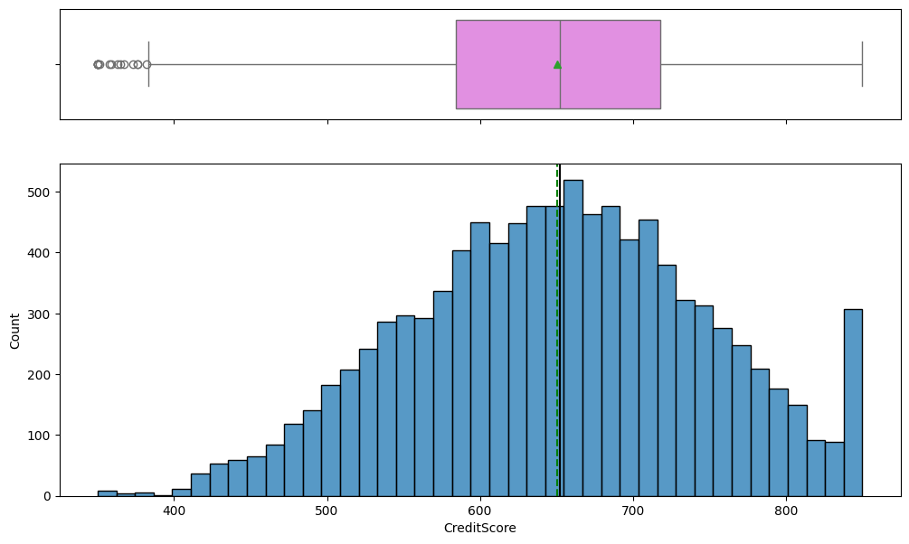

```python
histogram_boxplot(df,'CreditScore')
```

The credit score is largely centered around 650 (approximately ranging from 580 to 720), with a fairly normal distribution but some left skewness and a few lower side outliers.

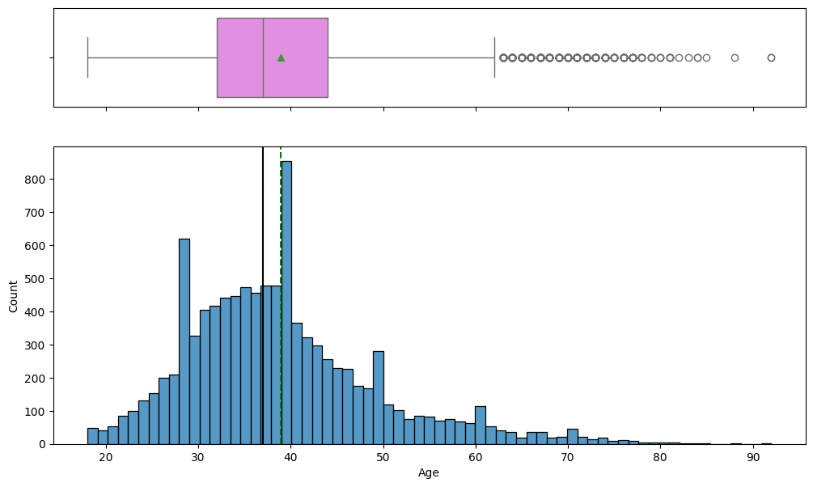

```python
histogram_boxplot(df,'Age')
```

- The age distribution shows two prominent groups: younger adults in their late 20s to early 30s, and middle-aged individuals around 40 years old. The two distinct age groups, possibly indicating different demographic segments.
- The data is slightly skewed to the right, with a few outliers in the older age range.

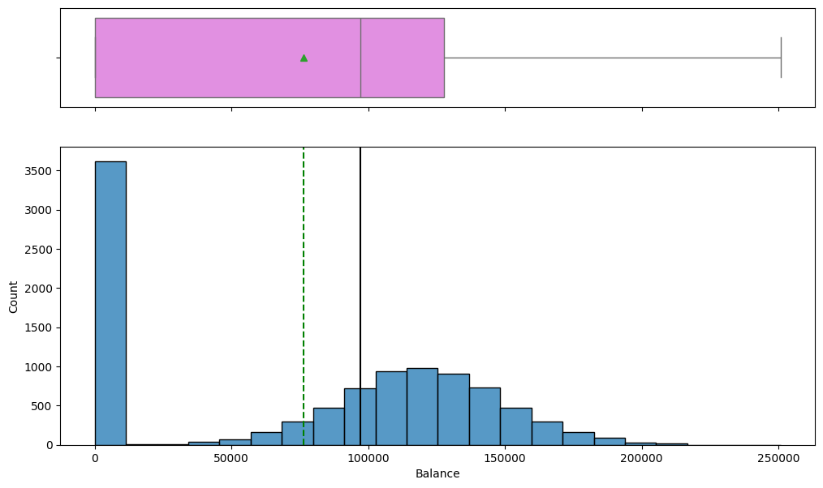

```python
histogram_boxplot(df,'Balance')
```

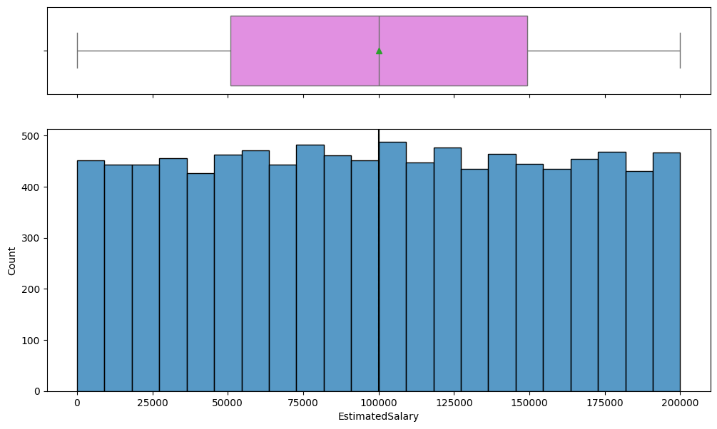

```python
histogram_boxplot(df,'EstimatedSalary')
```

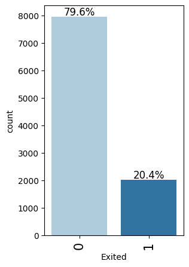

```python
labeled_barplot(df, "Exited", perc=True)
```

- The distribution of Exited (target variable) shows a significant imbalance in the data, with approximately 79.6% of the observations falling into the "0" category and 20.4% in the "1" category.
- This indicates a substantial difference in the proportion of individuals who exited compared to those who did not

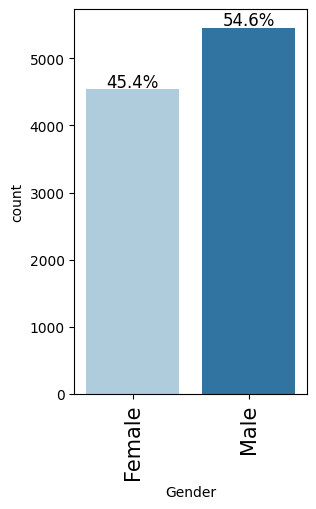

```python
labeled_barplot(df, "Gender", perc=True)
```

- The distribution of gender shows a noticeable imbalance, with a higher proportion of males (54.6%) compared to females (45.4%).

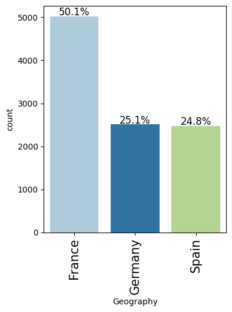

```python
labeled_barplot(df, "Geography", perc=True)
```

- The distribution of customers across three countries (France, Germany, and Spain) shows that France has the highest number of customers, representing 50.1% of the total. Germany follows with 25.1%, and Spain with 24.8%.
- There is a significant difference in customer count between France and the other two countries.

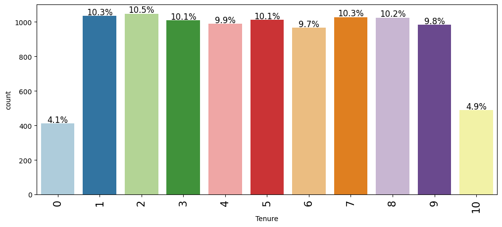

```python
labeled_barplot(df, "Tenure", perc=True)
```

- The distribution of customer's tenure in years exhibits a relatively uniform distribution across the tenure period, with a slight increase in frequency for tenures 1 to 8 years.
- A notable drop is observed for tenure 10, suggesting a potential churn or attrition issue for customers reaching the 10-year mark

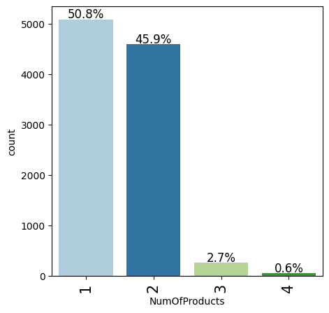

```python
labeled_barplot(df, "NumOfProducts", perc=True)
```

- A significant majority of customers (50.8%) have purchased only one product. The second most common category is two products (45.9%), followed by a considerably smaller percentage of customers purchasing three (2.7%) and four (0.6%) products.
- This indicates a strong concentration of customers with one or two products.

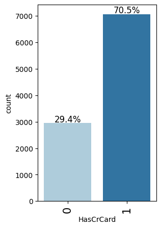

```python
labeled_barplot(df, "HasCrCard", perc=True)
```

A majority (70.5%) of the customers have a credit card which indicates a significant prevalence of credit card ownership.

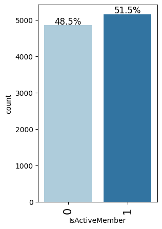

```python
labeled_barplot(df, "IsActiveMember", perc=True)
```

- There is a near-equal split between the two groups, with 48.5% of members being inactive and 51.5% being active.
- This suggests a relatively balanced distribution of active and inactive membership within the dataset

### Bivariate Analysis

```python
def stacked_barplot(data, predictor, target):
    """
    Print the category counts, plot a stacked bar chart, and perform a chi-square test.

    data: dataframe
    predictor: independent variable
    target: target variable
    """
    count = data[predictor].nunique()
    sorter = data[target].value_counts().index[-1]
    tab1 = pd.crosstab(data[predictor], data[target], margins=True).sort_values(
        by=sorter, ascending=False
    )
    print(tab1)
    print("-" * 50)
    tab = pd.crosstab(data[predictor], data[target], normalize="index").sort_values(
        by=sorter, ascending=False
    )
    tab.plot(kind="bar", stacked=True, figsize=(count + 1, 5))
    plt.legend(
        loc="lower left", frameon=False,
    )
    plt.legend(loc="upper left", bbox_to_anchor=(1, 1))

    # Perform chi-square test of independence
    contingency_table = pd.crosstab(data[predictor], data[target])
    chi2, p_value, _, _ = chi2_contingency(contingency_table)

    # Define significance level
    alpha = 0.05

    # Determine the hypothesis based on p-value
    if p_value < alpha:
        significance = "reject"
        statement = f"There is a significant association between {predictor} and {target} with p-value {p_value:.3f} < 0.05. \n We reject the null hypothesis."
    else:
        significance = "accept"
        statement = f"There is no significant association between {predictor} and {target} with p-value {p_value:.3f} > 0.05. \n We fail to reject the null hypothesis."

    # Add the statement at the bottom of the plot
    plt.figtext(0.5, -0.1, statement, ha='center', fontsize=10, bbox={"facecolor":"none", "alpha":0.5, "pad":5, "edgecolor": "none"})
    plt.tight_layout()
    plt.show()
    print("-" * 50)
```

```python
def distribution_plot_wrt_target(data, predictor, target):

    """
    Plots the distribution and relationship between a predictor and target variable.

    Parameters:
    - data: Dataset containing the predictor and target
    - predictor: Independent variable
    - target: target variable

    Calculates and displays the Pearson correlation coefficient and significance.
    """

    # Create a 2x2 grid of subplots
    fig, axs = plt.subplots(2, 2, figsize=(12, 10))

    target_uniq = data[target].unique()

    sns.histplot(
        data=data[data[target] == target_uniq[0]],
        x=predictor,
        kde=True,
        ax=axs[0, 0],
        color="teal",
        stat="density",
    )
    axs[0, 0].set_title("Distribution of target=" + str(target_uniq[0]))

    sns.histplot(
        data=data[data[target] == target_uniq[1]],
        x=predictor,
        kde=True,
        ax=axs[0, 1],
        color="orange",
        stat="density",
    )
    axs[0, 1].set_title("Distribution of target=" + str(target_uniq[1]))

    sns.boxplot(data=data, x=target, y=predictor, ax=axs[1, 0], palette="gist_rainbow")
    axs[1, 0].set_title("Boxplot w.r.t target")

    sns.boxplot(
        data=data,
        x=target,
        y=predictor,
        ax=axs[1, 1],
        showfliers=False,
        palette="gist_rainbow",
    )
    axs[1, 1].set_title("Boxplot (without outliers) w.r.t target")

    # Calculate Pearson correlation coefficient and p-value
    corr, p_value = stats.pearsonr(data[predictor], data[target])

    # Define significance level
    alpha = 0.05

    # Determine the hypothesis based on p-value
    if p_value < alpha:
        significance = "reject"
        statement = f"There is a significant difference between {predictor} and {target} with a correlation coefficient of {corr:.2f}, and p-value < 0.05. \n We reject the null hypothesis."
    else:
        significance = "accept"
        statement = f"There is no significant difference between {predictor} and {target} with a correlation coefficient of {corr:.2f}, and p-value > 0.05. \n We fail to reject the null hypothesis."

    # Print the statement at the bottom of the plot
    fig.text(0.1, -0.1, statement, ha='left')

    plt.tight_layout()
    plt.show()
    print("-" * 150)
```

### Correlation plot

```python
# defining the list of numerical columns
num_cols = ["CreditScore","Age","Tenure","Balance","EstimatedSalary"]
```

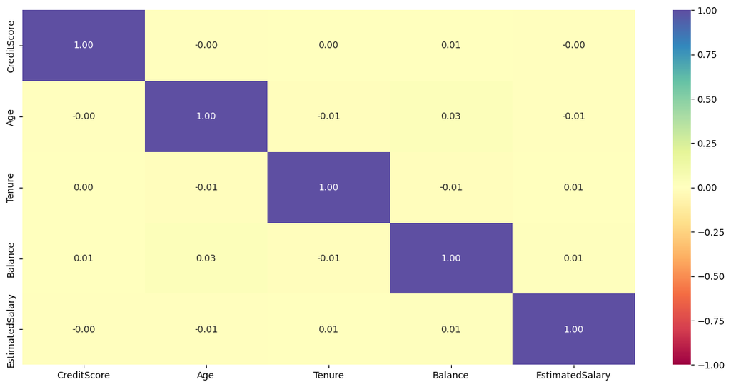

```python
plt.figure(figsize=(15, 7))
sns.heatmap(df[num_cols].corr(), annot=True, vmin=-1, vmax=1, fmt=".2f", cmap="Spectral")
plt.show()
```

- There are no strong positive or negative correlations present in the data which suggests that none of the variables significantly influence or predict the others.
- Given the absence of strong correlations, multicollinearity is unlikely to be a significant issue.

```python
df.columns
```

```
Index(['CreditScore', 'Geography', 'Gender', 'Age', 'Tenure', 'Balance',
       'NumOfProducts', 'HasCrCard', 'IsActiveMember', 'EstimatedSalary',
       'Exited'],
      dtype='object')
```

```
Exited        0     1    All
Geography
All        7963  2037  10000
Germany    1695   814   2509
France     4204   810   5014
Spain      2064   413   2477
--------------------------------------------------
```

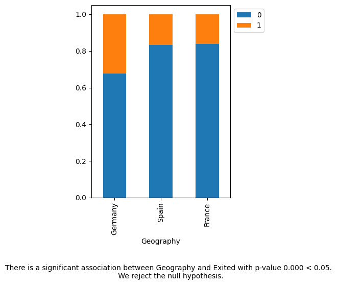

```
--------------------------------------------------
Exited     0     1    All
Gender
All     7963  2037  10000
Female  3404  1139   4543
Male    4559   898   5457
--------------------------------------------------
```

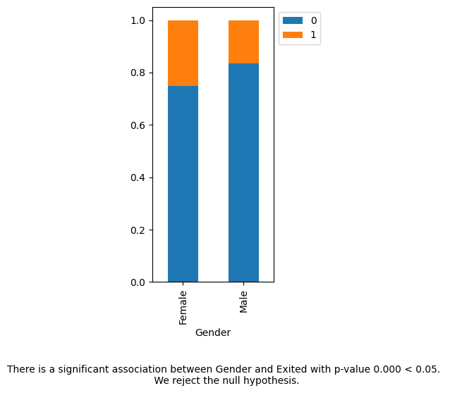

```
--------------------------------------------------
Exited        0     1    All
HasCrCard
All        7963  2037  10000
1          5631  1424   7055
0          2332   613   2945
--------------------------------------------------
```

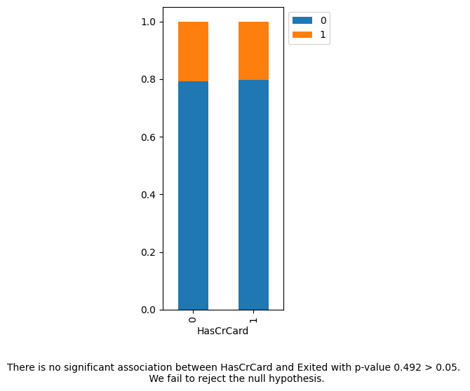

```
--------------------------------------------------
Exited             0     1    All
IsActiveMember
All             7963  2037  10000
0               3547  1302   4849
1               4416   735   5151
--------------------------------------------------
```

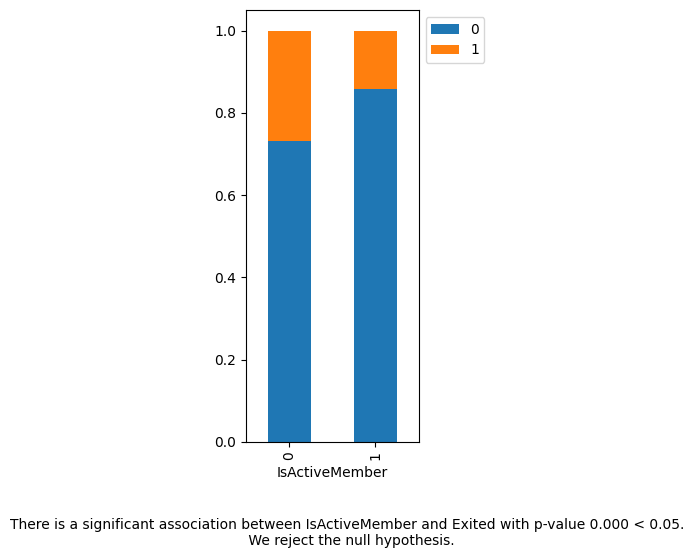

```
--------------------------------------------------
Exited            0     1    All
NumOfProducts
All            7963  2037  10000
1              3675  1409   5084
2              4242   348   4590
3                46   220    266
4                 0    60     60
--------------------------------------------------
```

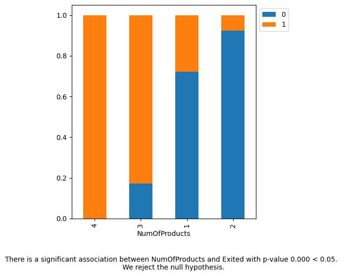

```python
# Variables to plot
cat_cols = ["Geography", "Gender", "HasCrCard", "IsActiveMember", "NumOfProducts"]

# Loop through each variable and create a stacked bar plot
for col in cat_cols:
    stacked_barplot(df, col, "Exited")
```